# Stutt verkefni 3

Adalheidur Magnusdottir

2023-02-13

```r
setwd("C:/Users/Aðalheiður/Desktop/TolfraediR")
```

```r
library(readr)
df <- read_csv("stutt_verkefni_3.csv",
    col_types = cols(...1 = col_skip()))
```

## Gagnasafnið sem unnið er með

Gagnasafnið byggir á ESS könnun og inniheldur 7 breytur.

Trstplc: Traust gagnvart lögreglu - 0 = ekkert traust; 10 = fullt traust

Age: Aldur - Fjöldi ára sem þátttakandi hefur verið á lífi

Eduyrs: Menntun - Fjöldi ára lokið í fullu námi

Hinctnt: Laun - Heildarlaun heimilis eftir allan frádrátt. Þó mæld á skalanum 1-12 en ekki í krónum.

Lrscale: Stjórnmálaafstaða - 0 = vinstrisinnun; 10 = hægri

Rlgdgr: Trú - 0 = trúlaus ; 10 = mikil trú

Socialtrust: Almennt traust gagnvart öðrum - 0 = vantraust gagnvart öðrum; 10 = treystir öðrum. Ath. Þetta er samsett breyta frá 3 öðrum breytum (einnig mældar á 1-10, meðaltal allra þriggja mælinga tekið fyrir hvern einstakling).

```r
str(df)
summary(df)

df <- na.omit(df)
summary(df)
```

## Tafla með upplýsingum um fylgni á milli allra breyta

```r
fylgni <- cor(df[,c("age","eduyrs","hinctnt","lrscale","rlgdgr","socialtrust", "trstplc")], use="complete.obs")
kable(fylgni, digits = 3) |> kable_styling()
```

|  | age | eduyrs | hinctnt | lrscale | rlgdgr | socialtrust | trstplc |
| --- | --- | --- | --- | --- | --- | --- | --- |
| age | 1.000 | -0.352 | -0.184 | -0.121 | 0.183 | 0.203 | 0.124 |
| eduyrs | -0.352 | 1.000 | 0.278 | 0.032 | -0.131 | -0.003 | -0.033 |
| hinctnt | -0.184 | 0.278 | 1.000 | 0.127 | -0.105 | 0.009 | 0.018 |
| lrscale | -0.121 | 0.032 | 0.127 | 1.000 | 0.094 | -0.099 | 0.051 |
| rlgdgr | 0.183 | -0.131 | -0.105 | 0.094 | 1.000 | 0.050 | 0.149 |
| socialtrust | 0.203 | -0.003 | 0.009 | -0.099 | 0.050 | 1.000 | 0.331 |
| trstplc | 0.124 | -0.033 | 0.018 | 0.051 | 0.149 | 0.331 | 1.000 |

Í töflunni má sjá fylgni á milli allra breyta. Bæði jákvæð og neikvæð fylgni er til staðar.

## Mynd af öllum breytunum

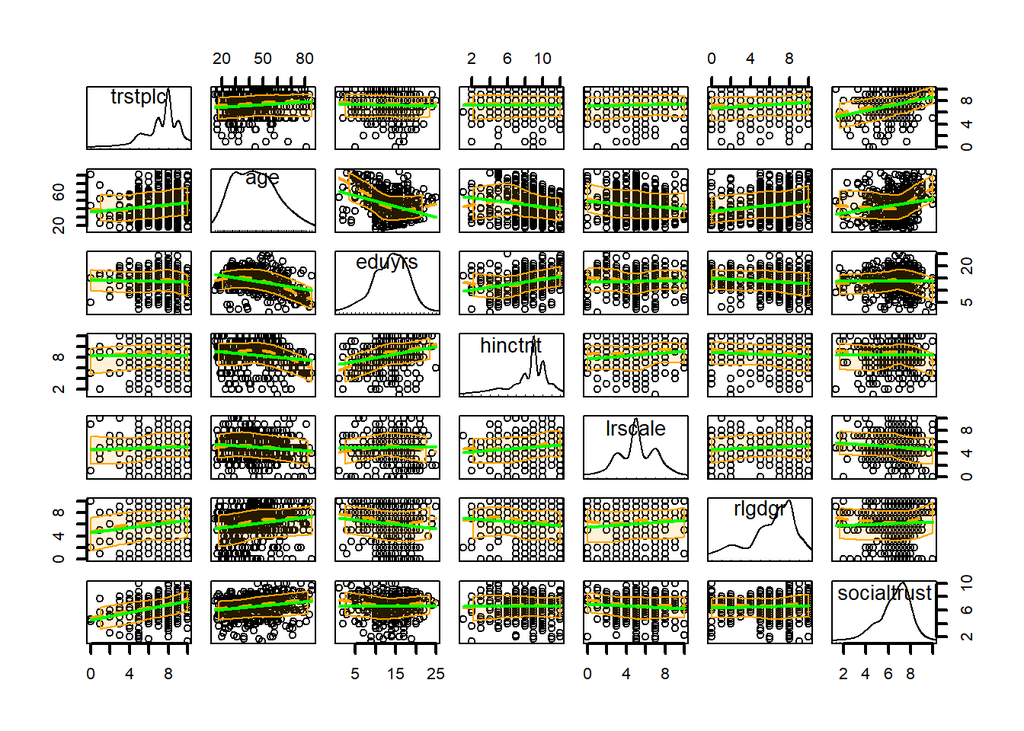

```r
car::scatterplotMatrix(~trstplc+age+eduyrs+hinctnt+lrscale+
                         rlgdgr+socialtrust, data=df, lwd=2,
                       col="black", regLine = list(col="green"),
                       smooth=list(col.smooth="orange", col.spread="orange"))
```

## Smíða einfalt líkan og bæta við (forward), þar sem traust gagnvart lögreglu er fylgibreytan

```r
lm.fit1 <- lm(trstplc ~ socialtrust, data = df)
summary(lm.fit1)
```

```
##
## Call:
## lm(formula = trstplc ~ socialtrust, data = df)
##
## Residuals:
##     Min      1Q  Median      3Q     Max
## -6.7235 -0.7235  0.2765  1.1956  4.7711
##
## Coefficients:
##             Estimate Std. Error t value Pr(>|t|)
## (Intercept)  4.70368    0.35833  13.127  < 2e-16 ***
## socialtrust  0.39389    0.05309   7.419 5.97e-13 ***
## ---
## Signif. codes:  0 '***' 0.001 '**' 0.01 '*' 0.05 '.' 0.1 ' ' 1
##
## Residual standard error: 1.746 on 448 degrees of freedom
## Multiple R-squared:  0.1094, Adjusted R-squared:  0.1074
## F-statistic: 55.04 on 1 and 448 DF,  p-value: 5.97e-13
```

```r
lm.fit2 <- lm(trstplc ~ socialtrust + age, data = df)
summary(lm.fit2)
```

```
##
## Call:
## lm(formula = trstplc ~ socialtrust + age, data = df)
##
## Residuals:
##     Min      1Q  Median      3Q     Max
## -6.8673 -0.7983  0.2753  1.1859  4.6652
##
## Coefficients:
##             Estimate Std. Error t value Pr(>|t|)
## (Intercept) 4.496121   0.391705  11.478  < 2e-16 ***
## socialtrust 0.379509   0.054180   7.005 9.15e-12 ***
## age         0.006788   0.005195   1.307    0.192
## ---
## Signif. codes:  0 '***' 0.001 '**' 0.01 '*' 0.05 '.' 0.1 ' ' 1
##
## Residual standard error: 1.744 on 447 degrees of freedom
## Multiple R-squared:  0.1128, Adjusted R-squared:  0.1088
## F-statistic: 28.42 on 2 and 447 DF,  p-value: 2.41e-12
```

```r
lm.fit3 <- lm(trstplc ~ socialtrust + age + rlgdgr, data = df)
summary(lm.fit3)
```

```
##
## Call:
## lm(formula = trstplc ~ socialtrust + age + rlgdgr, data = df)
##
## Residuals:
##     Min      1Q  Median      3Q     Max
## -6.9489 -0.8305  0.2390  1.1541  4.4084
##
## Coefficients:
##             Estimate Std. Error t value Pr(>|t|)
## (Intercept) 4.065299   0.417735   9.732  < 2e-16 ***
## socialtrust 0.377553   0.053770   7.022 8.22e-12 ***
## age         0.004182   0.005238   0.798  0.42502
## rlgdgr      0.090881   0.032277   2.816  0.00508 **
## ---
## Signif. codes:  0 '***' 0.001 '**' 0.01 '*' 0.05 '.' 0.1 ' ' 1
##
## Residual standard error: 1.731 on 446 degrees of freedom
## Multiple R-squared:  0.1283, Adjusted R-squared:  0.1224
## F-statistic: 21.88 on 3 and 446 DF,  p-value: 3.087e-13
```

Fyrst var breytan socialtrust notuð sem frumbreyta, síðan var breytunni age bætt við og að lokum rlgdgr.

## Samanburður á einföldum líkunum

```r
car::compareCoefs(lm.fit1, lm.fit2, lm.fit3, se= FALSE, digits= 2)
```

```
## Calls:
## 1: lm(formula = trstplc ~ socialtrust, data = df)
## 2: lm(formula = trstplc ~ socialtrust + age, data = df)
## 3: lm(formula = trstplc ~ socialtrust + age + rlgdgr, data = df)
##
##             Model 1 Model 2 Model 3
## (Intercept)     4.7     4.5     4.1
## socialtrust    0.39    0.38    0.38
## age                  0.0068  0.0042
## rlgdgr                        0.091
```

Hallastuðullinn á socialtraust lækkar þegar öðrum breytum var bætt við. Það sama á við um hallastuðullinn á breytunni age.

## Smíða flókið líkan og einfalda (backwards), þar sem traust gagnvart lögreglu var fylgibreytan.

```r
lm.fit4 <- lm(trstplc ~ socialtrust + rlgdgr + lrscale +  eduyrs
              + age + hinctnt, data = df)
summary(lm.fit4)
```

```
##
## Call:
## lm(formula = trstplc ~ socialtrust + rlgdgr + lrscale + eduyrs +
##     age + hinctnt, data = df)
##
## Residuals:
##     Min      1Q  Median      3Q     Max
## -7.1667 -0.8365  0.2499  1.1729  4.6008
##
## Coefficients:
##              Estimate Std. Error t value Pr(>|t|)
## (Intercept)  3.508900   0.647172   5.422 9.71e-08 ***
## socialtrust  0.383626   0.054120   7.088 5.39e-12 ***
## rlgdgr       0.085573   0.032677   2.619  0.00913 **
## lrscale      0.065666   0.040326   1.628  0.10415
## eduyrs      -0.004277   0.020587  -0.208  0.83551
## age          0.005467   0.005629   0.971  0.33195
## hinctnt      0.025453   0.039173   0.650  0.51619
## ---
## Signif. codes:  0 '***' 0.001 '**' 0.01 '*' 0.05 '.' 0.1 ' ' 1
##
## Residual standard error: 1.73 on 443 degrees of freedom
## Multiple R-squared:  0.1349, Adjusted R-squared:  0.1232
## F-statistic: 11.52 on 6 and 443 DF,  p-value: 5.475e-12
```

```r
lm.fit5 <- lm(trstplc ~ socialtrust + rlgdgr + lrscale +  eduyrs
              + age, data = df)
summary(lm.fit5)
```

```
##
## Call:
## lm(formula = trstplc ~ socialtrust + rlgdgr + lrscale + eduyrs +
##     age, data = df)
##
## Residuals:
##     Min      1Q  Median      3Q     Max
## -7.2209 -0.8306  0.2632  1.1907  4.4651
##
## Coefficients:
##              Estimate Std. Error t value Pr(>|t|)
## (Intercept)  3.678193   0.592021   6.213 1.20e-09 ***
## socialtrust  0.385152   0.054034   7.128 4.15e-12 ***
## rlgdgr       0.083990   0.032565   2.579   0.0102 *
## lrscale      0.068908   0.039990   1.723   0.0856 .
## eduyrs      -0.001251   0.020040  -0.062   0.9503
## age          0.005184   0.005608   0.924   0.3559
## ---
## Signif. codes:  0 '***' 0.001 '**' 0.01 '*' 0.05 '.' 0.1 ' ' 1
##
## Residual standard error: 1.729 on 444 degrees of freedom
## Multiple R-squared:  0.1341, Adjusted R-squared:  0.1243
## F-statistic: 13.75 on 5 and 444 DF,  p-value: 1.688e-12
```

```r
lm.fit6 <- lm(trstplc ~ socialtrust + rlgdgr + lrscale, data = df)
summary(lm.fit6)
```

```
##
## Call:
## lm(formula = trstplc ~ socialtrust + rlgdgr + lrscale, data = df)
##
## Residuals:
##     Min      1Q  Median      3Q     Max
## -7.0038 -0.8529  0.2534  1.1517  4.5272
##
## Coefficients:
##             Estimate Std. Error t value Pr(>|t|)
## (Intercept)  3.81373    0.45335   8.412  5.5e-16 ***
## socialtrust  0.39496    0.05288   7.469  4.3e-13 ***
## rlgdgr       0.09031    0.03186   2.835  0.00479 **
## lrscale      0.06394    0.03964   1.613  0.10747
## ---
## Signif. codes:  0 '***' 0.001 '**' 0.01 '*' 0.05 '.' 0.1 ' ' 1
##
## Residual standard error: 1.727 on 446 degrees of freedom
## Multiple R-squared:  0.1321, Adjusted R-squared:  0.1263
## F-statistic: 22.63 on 3 and 446 DF,  p-value: 1.177e-13
```

Í líkani 4 voru allar breyturnar til staðar, í líkani 5 var breytan hinctnt fjarlægð og í líkani 6 voru breyturnar hinctnt, age og eduyrs fjarlægðar.

## Samanburður á flóknum líkunum

```r
car::compareCoefs(lm.fit4, lm.fit5, lm.fit6, se= FALSE, digits= 2)
```

```
## Calls:
## 1: lm(formula = trstplc ~ socialtrust + rlgdgr + lrscale + eduyrs + age +
##   hinctnt, data = df)
## 2: lm(formula = trstplc ~ socialtrust + rlgdgr + lrscale + eduyrs + age,
##   data = df)
## 3: lm(formula = trstplc ~ socialtrust + rlgdgr + lrscale, data = df)
##
##             Model 1 Model 2 Model 3
## (Intercept)     3.5     3.7     3.8
## socialtrust    0.38    0.39    0.39
## rlgdgr        0.086   0.084   0.090
## lrscale       0.066   0.069   0.064
## eduyrs      -0.0043 -0.0013
## age          0.0055  0.0052
## hinctnt       0.025
```

Hallastuðullinn á breytunni socialtraust hækkar eftir því sem fleiri breytur voru fjarlægðar. Hallastuðull breytunnar rlgdgr lækkar á milli líkana 4 og 5 en hækkar svo aftur í líkani 6 en hallastuðullinn á breytunni lrscale hegðar sér akkúrat öfugt. Hallastuðlar eduyrs og age lækka báðir á milli líkanna 4 og 5 en hallastuðull þeirrar fyrri töluvert meira.

## Prufa styttingu og update skipunina

```r
lm.fit7 <- lm(trstplc ~., data=df)
summary(lm.fit7)
```

```
##
## Call:
## lm(formula = trstplc ~ ., data = df)
##
## Residuals:
##     Min      1Q  Median      3Q     Max
## -7.1667 -0.8365  0.2499  1.1729  4.6008
##
## Coefficients:
##              Estimate Std. Error t value Pr(>|t|)
## (Intercept)  3.508900   0.647172   5.422 9.71e-08 ***
## lrscale      0.065666   0.040326   1.628  0.10415
## rlgdgr       0.085573   0.032677   2.619  0.00913 **
## eduyrs      -0.004277   0.020587  -0.208  0.83551
## hinctnt      0.025453   0.039173   0.650  0.51619
## socialtrust  0.383626   0.054120   7.088 5.39e-12 ***
## age          0.005467   0.005629   0.971  0.33195
## ---
## Signif. codes:  0 '***' 0.001 '**' 0.01 '*' 0.05 '.' 0.1 ' ' 1
##
## Residual standard error: 1.73 on 443 degrees of freedom
## Multiple R-squared:  0.1349, Adjusted R-squared:  0.1232
## F-statistic: 11.52 on 6 and 443 DF,  p-value: 5.475e-12
```

```r
lm.fit8 <- update(lm.fit7, .~ . -age)
summary(lm.fit8)
```

```
##
## Call:
## lm(formula = trstplc ~ lrscale + rlgdgr + eduyrs + hinctnt +
##     socialtrust, data = df)
##
## Residuals:
##     Min      1Q  Median      3Q     Max
## -7.0099 -0.8636  0.2636  1.1682  4.6192
##
## Coefficients:
##             Estimate Std. Error t value Pr(>|t|)
## (Intercept)  3.78536    0.58118   6.513 2.00e-10 ***
## lrscale      0.06159    0.04010   1.536   0.1253
## rlgdgr       0.09019    0.03233   2.790   0.0055 **
## eduyrs      -0.01055    0.01955  -0.540   0.5898
## hinctnt      0.02250    0.03905   0.576   0.5648
## socialtrust  0.39427    0.05300   7.440 5.27e-13 ***
## ---
## Signif. codes:  0 '***' 0.001 '**' 0.01 '*' 0.05 '.' 0.1 ' ' 1
##
## Residual standard error: 1.73 on 444 degrees of freedom
## Multiple R-squared:  0.1331, Adjusted R-squared:  0.1233
## F-statistic: 13.63 on 5 and 444 DF,  p-value: 2.167e-12
```

## Prufa MASS pakkann

```r
library(MASS)
lm.forwards <- stepAIC(lm.fit4, direction = "forward", trace = FALSE)
summary(lm.forwards)
```

```
##
## Call:
## lm(formula = trstplc ~ socialtrust + rlgdgr + lrscale + eduyrs +
##     age + hinctnt, data = df)
##
## Residuals:
##     Min      1Q  Median      3Q     Max
## -7.1667 -0.8365  0.2499  1.1729  4.6008
##
## Coefficients:
##              Estimate Std. Error t value Pr(>|t|)
## (Intercept)  3.508900   0.647172   5.422 9.71e-08 ***
## socialtrust  0.383626   0.054120   7.088 5.39e-12 ***
## rlgdgr       0.085573   0.032677   2.619  0.00913 **
## lrscale      0.065666   0.040326   1.628  0.10415
## eduyrs      -0.004277   0.020587  -0.208  0.83551
## age          0.005467   0.005629   0.971  0.33195
## hinctnt      0.025453   0.039173   0.650  0.51619
## ---
## Signif. codes:  0 '***' 0.001 '**' 0.01 '*' 0.05 '.' 0.1 ' ' 1
##
## Residual standard error: 1.73 on 443 degrees of freedom
## Multiple R-squared:  0.1349, Adjusted R-squared:  0.1232
## F-statistic: 11.52 on 6 and 443 DF,  p-value: 5.475e-12
```

```r
lm.step <- stepAIC(lm.fit4, direction = "both", trace = F)
summary(lm.step)
```

```
##
## Call:
## lm(formula = trstplc ~ socialtrust + rlgdgr + lrscale, data = df)
##
## Residuals:
##     Min      1Q  Median      3Q     Max
## -7.0038 -0.8529  0.2534  1.1517  4.5272
##
## Coefficients:
##             Estimate Std. Error t value Pr(>|t|)
## (Intercept)  3.81373    0.45335   8.412  5.5e-16 ***
## socialtrust  0.39496    0.05288   7.469  4.3e-13 ***
## rlgdgr       0.09031    0.03186   2.835  0.00479 **
## lrscale      0.06394    0.03964   1.613  0.10747
## ---
## Signif. codes:  0 '***' 0.001 '**' 0.01 '*' 0.05 '.' 0.1 ' ' 1
##
## Residual standard error: 1.727 on 446 degrees of freedom
## Multiple R-squared:  0.1321, Adjusted R-squared:  0.1263
## F-statistic: 22.63 on 3 and 446 DF,  p-value: 1.177e-13
```

```r
lm.backward <- stepAIC(lm.fit4, direction = "backward", trace = F)
summary(lm.backward)
```

```
##
## Call:
## lm(formula = trstplc ~ socialtrust + rlgdgr + lrscale, data = df)
##
## Residuals:
##     Min      1Q  Median      3Q     Max
## -7.0038 -0.8529  0.2534  1.1517  4.5272
##
## Coefficients:
##             Estimate Std. Error t value Pr(>|t|)
## (Intercept)  3.81373    0.45335   8.412  5.5e-16 ***
## socialtrust  0.39496    0.05288   7.469  4.3e-13 ***
## rlgdgr       0.09031    0.03186   2.835  0.00479 **
## lrscale      0.06394    0.03964   1.613  0.10747
## ---
## Signif. codes:  0 '***' 0.001 '**' 0.01 '*' 0.05 '.' 0.1 ' ' 1
##
## Residual standard error: 1.727 on 446 degrees of freedom
## Multiple R-squared:  0.1321, Adjusted R-squared:  0.1263
## F-statistic: 22.63 on 3 and 446 DF,  p-value: 1.177e-13
```

## Áhrif aldurs þegar leiðrétt er fyrir með félagslegu trausti

```r
lm.age <- lm(trstplc ~ age, data = df)
summary(lm.age)
```

```
##
## Call:
## lm(formula = trstplc ~ age, data = df)
##
## Residuals:
##     Min      1Q  Median      3Q     Max
## -7.8088 -1.0289  0.4748  1.0846  3.0846
##
## Coefficients:
##             Estimate Std. Error t value Pr(>|t|)
## (Intercept) 6.660143   0.253391  26.284  < 2e-16 ***
## age         0.014181   0.005353   2.649  0.00835 **
## ---
## Signif. codes:  0 '***' 0.001 '**' 0.01 '*' 0.05 '.' 0.1 ' ' 1
##
## Residual standard error: 1.835 on 448 degrees of freedom
## Multiple R-squared:  0.01543,    Adjusted R-squared:  0.01323
## F-statistic: 7.019 on 1 and 448 DF,  p-value: 0.00835
```

```r
lm.age.social <- lm(trstplc ~ age + socialtrust, data = df)
summary(lm.age.social)
```

```
##
## Call:
## lm(formula = trstplc ~ age + socialtrust, data = df)
##
## Residuals:
##     Min      1Q  Median      3Q     Max
## -6.8673 -0.7983  0.2753  1.1859  4.6652
##
## Coefficients:
##             Estimate Std. Error t value Pr(>|t|)
## (Intercept) 4.496121   0.391705  11.478  < 2e-16 ***
## age         0.006788   0.005195   1.307    0.192
## socialtrust 0.379509   0.054180   7.005 9.15e-12 ***
## ---
## Signif. codes:  0 '***' 0.001 '**' 0.01 '*' 0.05 '.' 0.1 ' ' 1
##
## Residual standard error: 1.744 on 447 degrees of freedom
## Multiple R-squared:  0.1128, Adjusted R-squared:  0.1088
## F-statistic: 28.42 on 2 and 447 DF,  p-value: 2.41e-12
```

```r
car::compareCoefs(lm.age, lm.age.social, se = FALSE, digits=2)
```

```
## Calls:
## 1: lm(formula = trstplc ~ age, data = df)
## 2: lm(formula = trstplc ~ age + socialtrust, data = df)
##
##             Model 1 Model 2
## (Intercept)     6.7     4.5
## age          0.0142  0.0068
## socialtrust            0.38
```

Þegar félaglegu trausti er bætt við líkanið þá verður hallastuðullinn á breytunni age ómarktækur. Í samanburði á líkununum má sjá að hann lækkar einnig töluvert þegar félagslegu trausti er bætt við. Skýringarhlutfall hækkar töluvert á milli líkana, en það hækkar úr um 1% í um það bil 10% þegar félagslegu trausti er bætt við.

## Samanburður líkana - ANOVA

```r
anova(lm.fit1, lm.fit2)
```

```
## Analysis of Variance Table
##
## Model 1: trstplc ~ socialtrust
## Model 2: trstplc ~ socialtrust + age
##   Res.Df    RSS Df Sum of Sq      F Pr(>F)
## 1    448 1365.1
## 2    447 1360.0  1    5.1946 1.7074  0.192
```

```r
anova(lm.fit1, lm.fit3)
```

```
## Analysis of Variance Table
##
## Model 1: trstplc ~ socialtrust
## Model 2: trstplc ~ socialtrust + age + rlgdgr
##   Res.Df    RSS Df Sum of Sq     F   Pr(>F)
## 1    448 1365.1
## 2    446 1336.2  2    28.947 4.831 0.008401 **
## ---
## Signif. codes:  0 '***' 0.001 '**' 0.01 '*' 0.05 '.' 0.1 ' ' 1
```

Í samanburði á líkani 1 og líkani 3 er marktækur munur til staðar.

## Skoða AIC stuðullinn, sem athugar mátgæði

```r
AIC(lm.fit1, lm.fit2)
```

```
##         df      AIC
## lm.fit1  3 1782.439
## lm.fit2  4 1782.724
```

```r
AIC(lm.fit1, lm.fit3)
```

```
##         df      AIC
## lm.fit1  3 1782.439
## lm.fit3  5 1776.795
```

Í fyrri samanburðinum, á líkönum 1 og 2, má sjá að AIC stuðullinn er lægri í líkani 1, þar sem við erum bara með breytuna socialtrust. Munurinn er þó mjög smávægilegur. Það má álykta að munurinn sé svo smávægilegur þar sem aldur (age) er ekki að bæta við neinum upplýsingum við líkanið. Aldur gæti verið að mæla í raun það sama og félagsleg traust er að mæla. Í þessu tilviki ætti því að velja líkan 1.

Í seinni samanburðinum, á líkönum 1 og 3, er AIC stuðullinn lægri í líkani 3, þar sem breyturnar socialtrust, age og rlgdgr eru. Munurinn er mikill og því er seinna líkanið töluvert betra.